# Compendium of Legislation Applicable to Pacific Salmon and Ecosystems (CoLAPSE)

Technical Brief

Joe Enns, Cory Lagasse

2025-06-10

# INTRODUCTION

## Background

Resource conservation and stewardship in Canada is governed through a decentralized, multi-sector array of constitutional authority administered through federal, provincial, territorial, and municipal governments (Ray et al 2021; Campbell and Thomas 2002). Stemming from the Constitution Act, legislative control over ecological conservation has been a reactionary process of assigning authority to multiple jurisdictions over new environmental issues as they arise, which creates a complex and overlapping distribution of governance (Becklumb 2013). This patchwork of authority is most prominent in Pacific salmon management due to the complicated geographic nature of their anadromous life cycle, spanning a variety of freshwater and marine ecosystems coast-wide and across international boundaries.

While legislation and programs may often operate on a sector-by-sector and individual resource basis, integrated stewardship relies on scale-appropriate planning and decision making (Ray et al 2021). The need for collaborative, transparent decision-making in salmon management is recognized throughout policies, plans, and initiatives, such as the Pacific Salmon Strategy Initiative and the Wild Salmon Policy. Successful conservation and rebuilding of Pacific salmon therefore requires coordination of activities across discrete administrative responsibilities and regulatory frameworks. However, such coordination requires adequate organizational capacity and systems for effective implementation to ensure that regulatory controls and mitigation activities address underlying threats and factors limiting productivity.

In this report, we present a framework for relating threats to salmon with their legislative and regulatory context within British Columbia. We define discrete areas of administrative responsibility for Pacific salmon as “management domains” and conduct a review of legislation to assess the specificity or scope of each clause in relation to Pacific salmon. Our purpose for creating a management domains framework is to:

- facilitate a better understanding of the legislative and regulatory context through which Pacific salmon and their ecosystems are governed in British Columbia;
- relate Pacific salmon threat categories to legislation; and
- support comprehensive management and conservation planning for Pacific salmon by assigning discrete areas for the administration of human activities across jurisdictions.

# METHODS

## Defining Management Domains

Management domains represent a reframing of multi-jurisdictional issues by administrative concern rather than specific agency, which can mainstream conservation strategies focused on threats to salmon life history. Since management domains are defined as a “separation of administrative concerns,” it is important that each domain is categorized distinctly to minimize grey areas and blurring between individual domains or the exercise would fail to be useful. Aside from aspects of governance and organizational structure, 13 specific management domains were delineated for the purpose of this exercise. The domains were developed to comprehensively encompass the legislative context, administrative functions, and anthropogenic threats related to Pacific salmon in British Columbia.

We used the International Union for Conservation of Nature (IUCN) threat categories (Salafsky et al 2008) to classify legislation into anthropogenic activities that affect salmon. IUCN threat categories are widely used to assess threats as part of IUCN red list assessments, as well as in status assessments for Pacific salmon populations conducted by the Committee for the Status of Endangered Wildlife in Canada (COSEWIC). We assigned level 1 and level 2 threat classification hierarchies from the IUCN categories into management domains to separate anthropogenic activities into different areas of administrative concern.

- Aquaculture and Hatcheries
- Climate Change and Natural Disasters
- Fisheries
- Forest and Range
- Governance, Policy, and Organizational Structure
- Human Disturbance
- Invasive Species and Disease
- Mining and Energy
- Pollution
- Spatial Designation
- Species Status and Assessment
- Transportation Infrastructure
- Water Use and Watercourse Modifications

Historically, much of the management decisions and activities related to salmon have been in response to identifiable threats to salmon health and population status. One common framework used to describe impacts to salmon are the Four H’s: Habitat, Hydropower, Harvest, and Hatcheries. Each management domain, as defined in this report, intentionally aligns with one of the four H’s. However, there are aspects of salmon management associated with governance and agreements rather than one of the other H’s, which was categorized as “Handshaking.” Because the management domains are centered around salmon/habitat impacts, this allows structurally for a clearer alignment with IUCN threat categories.

Flowchart showing alignment of Pacific salmon threat factors (Four H’s) with Management Domains in relation to legislation and jurisdiction.

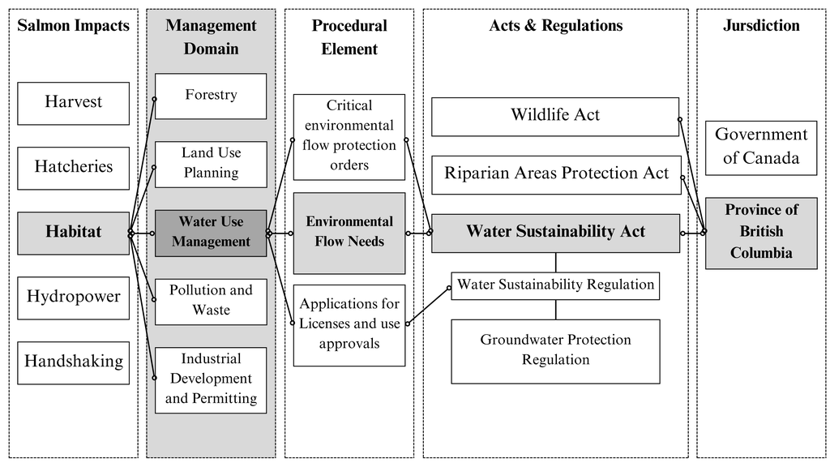

## Process

Assessment of legislative context is prone to subjective interpretation. The inclusion and exclusion of both the overall acts and the sections within the acts creates points of assumption and bias. For this exercise we cast as wide a net as possible and created a process that is publicly accessible, automated, and repeatable. Other researchers may repeat this process as future legislation and language changes. The process steps are:

1. Legislation Accumulation and Review (CanLii)
2. Parsing Legislation by Section and Heading (R)
3. Assigning Management Domain and IUCN Threats (R)
- Building a Keyword List
- Assigning to Sections/Subsections (R)
4. Assigning Scope (R)
5. Assigning Clause Type (R)

### 1) Legislation Accumulation and Review

We focused our review on established Canadian federal and British Columbian provincial legislation (acts and regulations) for inclusion in the management domain process. We did not include specific departmental policy frameworks and processes throughout this exercise unless specifically referenced in the statutes, because these executive strategies are prone to changes in the political, administrative, and budgetary landscape. Indigenous legislation, Yukon Territorial legislation, municipal bylaws, and international conventions were not included explicitly. Although these laws are important for management of Pacific salmon, considering these regionally diverse rules was outside the scope of this legislative review.

The Canadian Legal Information Institute website, [CanLII](https://www.canlii.org/), provides an excellent resource for searching federal and provincial acts and regulations by keywords. We created a systematic process for querying legislation by:

1. querying Pacific salmon specific terms (salmon, chinook, sockeye, etc.), which we called “Type A Legislation,”
2. extracting adjacent keywords from the Type A Legislation (word frequency analysis),
3. querying new keywords and IUCN Threat keywords in CanLII to find “Type B Legislation” (doesn’t mention salmon by name),
4. filtering legislation regionally (excluding provinces other than BC), and
5. downloading HTML files for relevant legislation directly from government websites.

Through the CanLII website, the user may look up the keywords queried in each act and regulation chosen. This allows the user to quickly assess the context of the word in the legislation and determine if the section is relevant to Pacific salmon. The full list of legislation reviewed in this process is available in Appendix I.

### 2) Parsing Legislation from HTML Files

The decentralized overlapping patchwork of Pacific salmon legislation in Canada creates a dynamic such that each act and regulation may contain a variety of administrative responsibilities, possibly attributed to different agencies. However, each act and regulation is comprised of sections and subsections that contain individual clauses that are more specific to a particular subject. For the purpose of the review, we used the individual clause as the sample unit for assignment into management domains and other corresponding attributes.

We parsed the HTML files using R and the `rvest` package to extract the text of each section and subsection grouped by heading. The text was then cleaned and standardized to remove any extraneous characters or formatting issues. Each section was assigned a unique identifier, and metadata such as the act name, jurisdiction, and legislation type (act or regulation) were recorded.

### 3) Assigning Management Domains and IUCN Threats from Keywords

The Management Domains and IUCN threats were assigned to each section based on a keyword list developed from the IUCN threat categories. The keywords were used to identify specific sections and subsections within the legislation. Each section was then assigned to one or more Management Domain and IUCN threat based on the presence of these keywords.Iteratively, we adjusted the keyword list to ensure that it accurately captured the scope of each Management Domain and IUCN threat. The keyword list is available in Appendix II.

### 4) Assigning Scope

We developed a scope classification system to categorize the sections based on their relevance to Pacific salmon. The scope was determined by the specificity of the language used in the section. The Scope categories were defined as follows:

1. Salmon - refers to salmon specifically
2. Fish - refers to fish that include salmon
3. Habitat - refers to any habitat that includes salmon habitat
4. Governance - refers to administrative processes and structure

Scope 1 was assigned separately to sections with the specific salmon keywords. Scope 2-3 were assigned during the Management Domain and IUCN Threat assignment.

### 5) Assigning Clause Type from Keywords

Similar the Management Domain assignment, we created a Clause Type keyword list to assess the nature or purposes of the clauses. Using language patterns within the legislation, we grouped Clause Type by:

- Administration, Application, & Structure
- Authorization & Mandate
- Designation
- Instruction
- Interpretation & Purpose
- Licence, Permitting, & Exemptions
- Prohibition, Restriction, or Limitation

# RESULTS

## 1) Compendium of Legislation Applicable to Pacific Salmon and Ecosystems (CoLAPSE)

### Procedural Element Count by Scope

- **1 - Salmon:** 99 Procedural Elements
- **2 - Fish:** 1641 Procedural Elements
- **3 - Habitat:** 2939 Procedural Elements
- **4 - Governance:** 1589 Procedural Elements

Using the ‘1 - Salmon’ scope for Procedural Elements shows the Type A Legislation along with a comparison of the number of Procedural Elements by Jurisdiction. The results are shown in the bar chart below, which displays the number of Procedural Elements for each piece of legislation that is specific to salmon. The chart is color-coded by jurisdiction (Federal or Provincial) to highlight the distribution of Procedural Elements across different legislative frameworks.

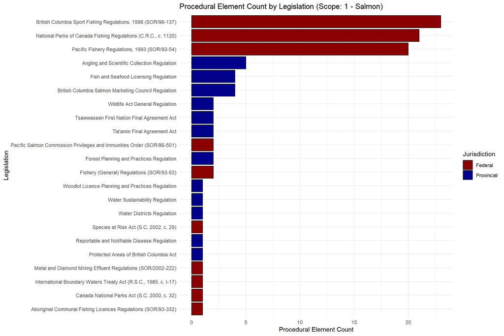

## Summary of Management Domains

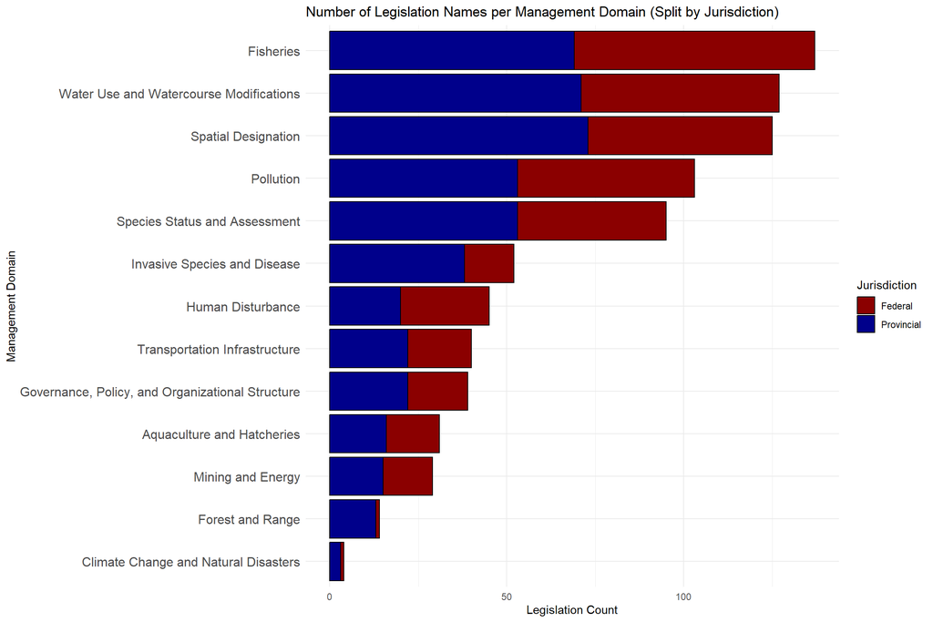

## Summary of IUCN Threats

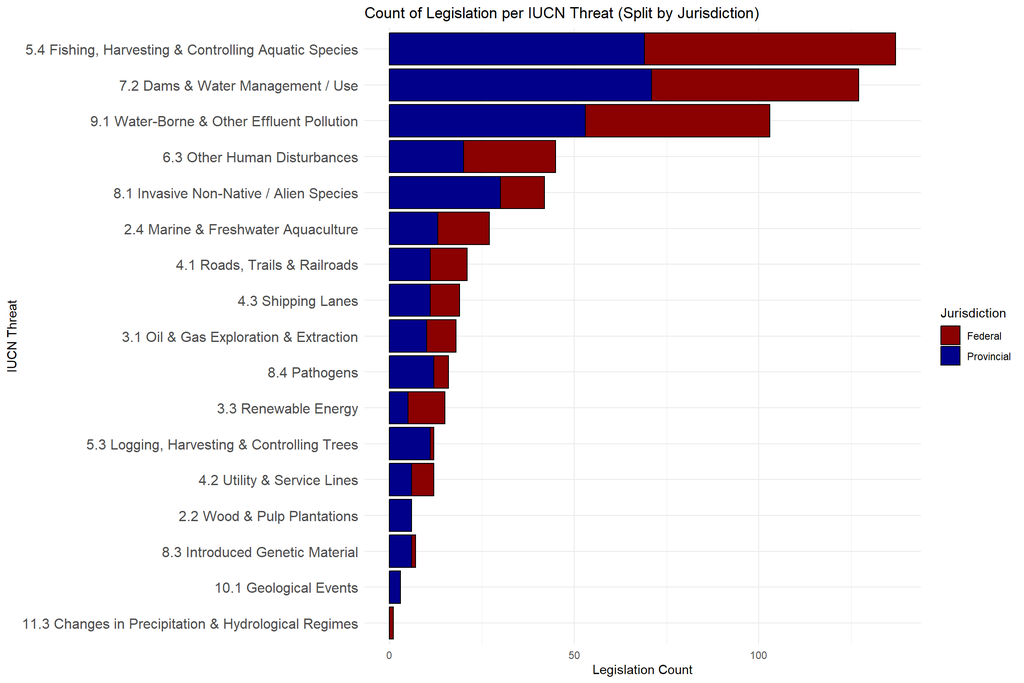

## Summary of Clause Types

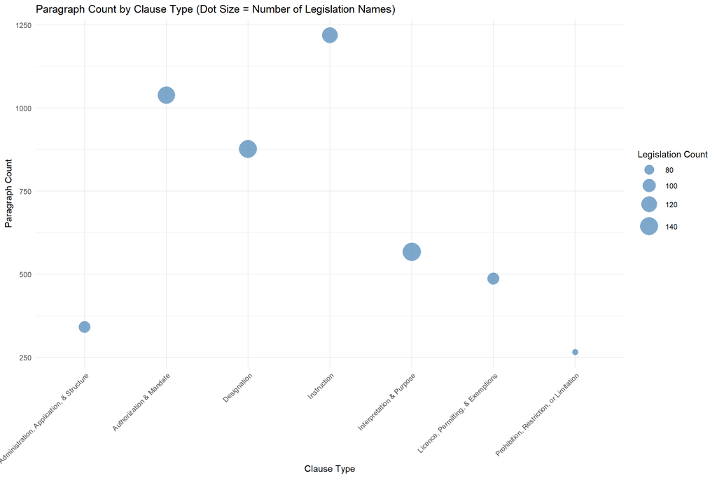

# REFERENCES

Armitage, D., de Loë, R., Plummer, R., 2012. Environmental governance and its implications for conservation practice. Conserv. Lett. 5, 245–255.

Beazley, K.F., and Olive, A. 2021. Transforming conservation in Canada: shifting policies and paradigms. FACETS, 6: 1714–1727. doi:10.1139/ facets-2021-0144.

Becklumb, P. 2013. Federal and provincial jurisdiction to regulate environmental issues. Ottawa.

Bennett NJ, Roth R, Klain SC, Chan K, Christie P, Clark DA, et al. 2017a. Conservation social science: understanding and integrating human dimensions to improve conservation. Biological Conservation, 205: 93–108. DOI: 10.1016/j.biocon.2016.10.006

Campbell ML, and Thomas VG. 2002. Constitutional impacts on conservation—effects of federalism on biodiversity protection. Environment Policy and Law, 32: 223–233.

Collins L, and Sossin L. 2019. Approach to constitutional principles and environmental discretion in Canada. UBC Law Review, 52(1): 293–343. [online]: Available from digitalcommons.osgoode.yorku.ca

Dufresne Y, and Ouellet C. 2019. Conceptualization, measurement and effects of positional issues in the Canadian electoral context. Heliyon, 5(4): e01453. PMID:31025009. DOI:10.1016/j.heliyon. 2019.e01453

Kraus, D., Murphy, S., and Armitage, D. 2021. Ten bridges on the road to recovering Canada’s endangered species. doi:10.1139/facets.

Hutchings JA, Côté IM, Dodson JJ, Fleming IA, Jennings S, Mantua NJ, et al. 2012. Is Canada fulfilling its obligations to sustain marine biodiversity? A summary review, conclusions, and recommendations. Environmental Reviews 20: 353–361. DOI: 10.1139/er-2012-0049

Marentette, J.R. and Kronlund, A.R. 2020. A Cross-Jurisdictional Review of International Fisheries Policies, Standards and Guidelines: Considerations for a Canadian Science Sector Approach. Can. Tech. Rep. Fish. Aquat. Sci. 3342: xiii + 169 p.

McCune JL, Harrower WL, Avery-Gomm S, Brogan JM, Csergő A-M, Davidson LNK, et al. 2013. Threats to Canadian species at risk: an analysis of finalized recovery strategies. Biological Conservation, 166: 254–265. DOI: 10.1016/j.biocon.2013.07.006

Ray, J.C., Grimm, J., and Olive, A. 2021. The biodiversity crisis in Canada: failures and challenges of federal and sub-national strategic and legal frameworks. FACETS. 6: 1044–1068. doi:10.1139/facets.

Salafsky, N., Salzer, D., Stattersfield, A.J., Hilton-Taylor, C., Nuegarten, R., Butchart, S.H.M., Collen, B., Cox, N., Master, L.L., O’Connor, S., Wilkie, D., 2008. A standard lexicon for biodiversity conservation: unified classifications of threats and actions. Conserv. Biol. 22, 897–911.

Swerdfager, Trevor, and Andrea Olive. “Laws Matter: A Foundational Approach to Biodiversity Conservation in Canada.” Edited by David Lesbarreres. FACETS 8 (January 1, 2023): 1–13.

Westwood AR, Otto SP, Mooers A, Darimont C, Hodges KE, Johnson C, et al. 2019. Protecting biodiversity in British Columbia: recommendations for developing species at risk legislation. FACETS, 4(1): 136–160. DOI: 10.1139/facets-2018-0042

# Appendix I - Legislation Accumulation and Review

## Acts per Jurisdiction

- **Provincial:** 44 Acts
- **Federal:** 27 Acts

## Acts and Their Regulations by Jurisdiction

Federal

**Canada National Marine Conservation Areas Act**  
No regulations included

**Canada National Parks Act**  
National Historic Parks General Regulations (SOR/82-263)  
National Parks General Regulations (SOR/78-213)  
National Parks of Canada Fishing Regulations (C.R.C., c. 1120)  
National Parks of Canada Water and Sewer Regulations (C.R.C., c. 1134)  
National Parks Wildlife Regulations (SOR/81-401)

**Canada Oil And Gas Operations Act**  
No regulations included

**Canada Shipping Act, 2001**  
Ballast Water Regulations (SOR/2021-120)  
Cross-border Movement of Hazardous Waste and Hazardous Recyclable Material Regulations (SOR/2021-25)  
Environmental Response Regulations (SOR/2019-252)  
Fishing Vessel Safety Regulations (C.R.C., c. 1486)  
Vessel Pollution and Dangerous Chemicals Regulations (SOR/2012-69)

**Canada Water Act**  
No regulations included

**Canada Water Agency Act**  
No regulations included

**Canada Wildlife Act**  
Wildlife Area Regulations (C.R.C., c. 1609)

**Canadian Energy Regulator Act**  
No regulations included

**Canadian Environmental Protection Act, 1999**  
Disposal at Sea Permit Application Regulations (SOR/2014-177)  
Disposal at Sea Regulations (SOR/2001-275)  
Environmental Emergency Regulations, 2019 (SOR/2019-51)  
Microbeads in Toiletries Regulations (SOR/2017-111)  
New Substances Notification Regulations (Organisms) (SOR/2005-248)  
PCB Regulations (SOR/2008-273)  
Persistence and Bioaccumulation Regulations (SOR/2000-107)  
Prohibition of Certain Toxic Substances Regulations, 2012 (SOR/2012-285)  
Storage Tank Systems for Petroleum Products and Allied Petroleum Products Regulations (SOR/2008-197)

**Canadian Navigable Waters Act**  
Navigable Waters Works Regulations (C.R.C., c. 1232)

**Coastal Fisheries Protection Act**  
Coastal Fisheries Protection Regulations (C.R.C., c. 413)

**Dominion Water Power Act**  
Dominion Water Power Regulations (C.R.C., c. 1603)

**Fisheries Act**  
Aboriginal Communal Fishing Licences Regulations (SOR/93-332)  
Aquaculture Activities Regulations (SOR/2015-177)  
Aquatic Invasive Species Regulations (SOR/2015-121)  
Authorizations Concerning Fish and Fish Habitat Protection Regulations (SOR/2019-286)  
British Columbia Sport Fishing Regulations, 1996 (SOR/96-137)  
Fish Toxicant Regulations (SOR/88-258)  
Fishery (General) Regulations (SOR/93-53)  
Foreign Vessel Fishing Regulations (C.R.C., c. 815)  
Management of Contaminated Fisheries Regulations (SOR/90-351)  
Marine Mammal Regulations (SOR/93-56)  
Meat and Poultry Products Plant Liquid Effluent Regulations (C.R.C., c. 818)  
Metal and Diamond Mining Effluent Regulations (SOR/2002-222)  
Pacific Aquaculture Regulations (SOR/2010-270)  
Pacific Fishery Management Area Regulations, 2007 (SOR/2007-77)  
Pacific Fishery Regulations, 1993 (SOR/93-54)  
Petroleum Refinery Liquid Effluent Regulations (C.R.C., c. 828)  
Pulp and Paper Effluent Regulations (SOR/92-269)  
Regulations Establishing Conditions for Making Regulations Under Subsection 36(5.2) of the Fisheries Act (SOR/2014-91)  
Wastewater Systems Effluent Regulations (SOR/2012-139)

**Fisheries Development Act**  
No regulations included

**Fishing And Recreational Harbours Act**  
Fishing and Recreational Harbours Regulations (SOR/78-767)

**Foreign Missions And International Organizations Act**  
No regulations included

**Freshwater Fish Marketing Act**  
No regulations included

**Impact Assessment Act**  
Physical Activities Regulations (SOR/2019-285)

**International Boundary Waters Treaty Act**  
International Boundary Waters Regulations (SOR/2002-445)

**International River Improvements Act**  
International River Improvements Regulations (C.R.C., c. 982)

**Maanulth First Nations Final Agreement Act**  
No regulations included

**Oceans Act**  
Bowie Seamount Marine Protected Area Regulations (SOR/2008-124)

**Parks Canada Agency Act**  
No regulations included

**Pest Control Products Act**  
Pest Control Products Regulations (SOR/2006-124)

**Species At Risk Act**  
Permits Authorizing an Activity Affecting Listed Wildlife Species Regulations (SOR/2013-140)

**Transportation Of Dangerous Goods Act, 1992**  
Transportation of Dangerous Goods by Rail Security Regulations (SOR/2019-113)  
Transportation of Dangerous Goods Regulations (SOR/2001-286)

**Wrecked, Abandoned Or Hazardous Vessels Act**  
No regulations included

Provincial

**Agricultural Land Commission Act**  
Agricultural Land Reserve General Regulation  
Agricultural Land Reserve Use Regulation

**Animal Health Act**  
Animal Products and Byproducts Regulation  
Reportable and Notifiable Disease Regulation

**Assessment Act**  
No regulations included

**Dike Maintenance Act**  
No regulations included

**Drainage, Ditch And Dike Act**  
No regulations included

**Drinking Water Protection Act**  
Drinking Water Protection Regulation

**Ecological Reserve Act**  
Ecological Reserve Regulation

**Emergency And Disaster Management Act**  
No regulations included

**Energy Resource Activities Act**  
Dormancy and Shutdown Regulation  
Emergency Management Regulation  
Energy Resource Road Regulation  
Environmental Protection and Management Regulation

**Environment And Land Use Act**  
No regulations included

**Environmental Assessment Act**  
Reviewable Projects Regulation

**Environmental Management Act**  
Antisapstain Chemical Waste Control Regulation  
Conservation Officer Service Authority Regulation  
Contaminated Sites Regulation  
Environmental Data Quality Assurance Regulation  
Land-based Finfish Waste Control Regulation  
Pulp Mill and Pulp and Paper Mill Liquid Effluent Control Regulation  
Spill Contingency Planning Regulation  
Spill Preparedness, Response and Recovery Regulation  
Spill Reporting Regulation  
Waste Discharge Regulation

**Farm Practices Protection Act**  
Specialty Farm Operations Regulation

**Farming And Fishing Industries Development Act**  
British Columbia Salmon Marketing Council Regulation

**Federal Port Development Act**  
No regulations included

**Fish And Seafood Act**  
Fish and Seafood Licensing Regulation

**Fishing Collective Bargaining Act**  
No regulations included

**Flood Relief Act**  
No regulations included

**Forest Act**  
No regulations included

**Forest And Range Practices Act**  
Forest Planning and Practices Regulation  
Forest Service Road Use Regulation  
Government Actions Regulation  
Invasive Plants Regulation  
Range Planning and Practices Regulation  
Woodlot Licence Planning and Practices Regulation

**Forest Practices Code Of British Columbia Act**  
Provincial Forest Use Regulation

**Greenbelt Act**  
No regulations included

**Hydro And Power Authority Act**  
No regulations included

**Hydro Power Measures Act**  
No regulations included

**Integrated Pest Management Act**  
Integrated Pest Management Regulation

**Land Act**  
Land Use Objectives Regulation

**Libby Dam Reservoir Act**  
No regulations included

**Mines Act**  
No regulations included

**Natural Resource Compliance Act**  
Natural Resource Officer Authority Regulation

**Park Act**  
Class C Parks Regulations

**Private Managed Forest Land Act**  
Private Managed Forest Land Council Matters Regulation  
Private Managed Forest Land Council Regulation

**Professional Governance Act**  
Agrologists Regulation  
Applied Biologists Regulation  
Applied Science Technologists and Technicians Regulation  
Engineers and Geoscientists Regulation

**Protected Areas Of British Columbia Act**  
No regulations included

**Railway Act**  
No regulations included

**Range Act**  
Range Regulation

**Riparian Areas Protection Act**  
Riparian Areas Protection Regulation

**The Hunting And Fishing Heritage Act**  
No regulations included

**Tla’amin Final Agreement Act**  
No regulations included

**Transport Of Dangerous Goods Act**  
No regulations included

**Transportation Act**  
No regulations included

**Tsawwassen First Nation Final Agreement Act**  
No regulations included

**Water Protection Act**  
No regulations included

**Water Sustainability Act**  
Dam Safety Regulation  
Groundwater Protection Regulation  
Water Districts Regulation  
Water Sustainability Regulation

**Wildlife Act**  
Angling and Scientific Collection Regulation  
Controlled Alien Species Regulation  
Designation of Officers Regulation  
Management Unit Regulation  
Wildlife Act Commercial Activities Regulation  
Wildlife Act General Regulation  
Wildlife Management Areas Regulation

# Appendix II - Management Domain Keyword List

## Management Domains & IUCN Threats

### Agriculture

**2. Agriculture & Aquaculture:** 2.1 Annual & Perennial Non-Timber Crops

### Aquaculture and Hatcheries

**2. Agriculture & Aquaculture:** 2.4 Marine & Freshwater Aquaculture

**8. Invasive / Other Problematic Species, Genes & Pathogens:** 8.3 Introduced Genetic Material

### Climate Change and Natural Disasters

**10. Natural Disasters:** 10.1 Geological Events

**11. Climate Change:** 11.1 Changes in Physical & Chemical Regimes

**11. Climate Change:** 11.3 Changes in Precipitation & Hydrological Regimes

### Fisheries

**5. Biological Resource Use & Control:** 5.4 Fishing, Harvesting & Controlling Aquatic Species

### Forest and Range

**2. Agriculture & Aquaculture:** 2.2 Wood & Pulp Plantations

**2. Agriculture & Aquaculture:** 2.3 Terrestrial Animal Farming, Ranching & Herding

**5. Biological Resource Use & Control:** 5.3 Logging, Harvesting & Controlling Trees

### Human Disturbance

**6. Human Intrusions & Disturbances:** 6.3 Other Human Disturbances

### Invasive Species and Disease

**8. Invasive / Other Problematic Species, Genes & Pathogens:** 8.1 Invasive Non-Native / Alien Species

**8. Invasive / Other Problematic Species, Genes & Pathogens:** 8.2 Problematic Native Species

**8. Invasive / Other Problematic Species, Genes & Pathogens:** 8.4 Pathogens

### Mining and Energy

**3. Energy Production & Mining:** 3.1 Oil & Gas Exploration & Extraction

**3. Energy Production & Mining:** 3.3 Renewable Energy

### Pollution

**9. Pollution:** 9.1 Water-Borne & Other Effluent Pollution

### Transportation Infrastructure

**4. Transportation, Service & Security Corridors:** 4.1 Roads, Trails & Railroads

**4. Transportation, Service & Security Corridors:** 4.2 Utility & Service Lines

**4. Transportation, Service & Security Corridors:** 4.3 Shipping Lanes

### Water Use and Watercourse Modifications

**7. Natural System Management & Modifications:** 7.2 Dams & Water Management / Use

## Keywords by Management Domain

### Agriculture

farm operation

### Aquaculture and Hatcheries

animal biproduct

animal health

animal product

aquaculture

artificial breeding

biochemical

breeding

finfish

fish feed

fish meal

genetically-modified

hatcheries

hatchery

net pen

pond

### Climate Change and Natural Disasters

CO2

acidification

drought

flood hazard

landslide

sea-level

temperature sensitive

### Fisheries

Fishing

angler

angling

bait

catch and retain

catches

caught fish

conservation stamp

dip net

dressed

fin fish

fish

fish for

fish guard

fish guards

fisheries

fishery

fishing

fishing guide

foul hook

frozen fish

gill net

guiding for fish

harvested salmon

incidental catch

incidental catch

kinds of fish

limit

live fish

possess fish

possession

protection of fish

quota

roe

salmon tag

seine

sport fishing

sportfish

stock

trawl

### Forest and Range

logging

plantation

pulpwood

range practrice

range stewardship

range use

### Governance, Policy, and Organizational Structure

committee

### Human Disturbance

research

### Invasive Species and Disease

alga

biocontrol

disease

exotic

feral

introduced

invasive

mussel

non-native

nonferal

outbreak

pathogen

pathogens

pest

virus

### Mining and Energy

drilling

tidal

### Pollution

chemical

deleterious

disposal

effluent

fertilizer

herbicide

leaching

leakage

manure

nutrient

pesticide

salinity

sedimentation

septic

sewage

spill

tailings

toxic

treatment

waste

water quality

### Spatial Designation

boundaries

boundary

classified waters

conservation area

conservation areas

district

ecological

environment

environmental

land reserve

land use

management unit

park reserve

park reserves

sensitive area

sensitive areas

zone

### Species Status and Assessment

biodiversity

concern

endangered

extinct

extirpated

fish stock

listed

risk

threatened

### Transportation Infrastructure

aqueduct

bridge

canals

causeway

channel

crossing

shipping lane

### Water Use and Watercourse Modifications

aquatic ecosystems

beaver

catch basin

catchment

channelization

culvert

dam

dams

desalination

dike

dikes

drinking

fish barrier

fish habitat

fish passage

flood control

flood plain

floodplain

flume

flumes

groundwater

lake

levee

passage of fish

pumping

rearing area

reservoir

riparian

river

storm water

stream

streamside

water

water use

watershed

wetland

# Appendix III - Clause Type Keywords

## Clause Type Keywords

### Administration, Application, & Structure

administration

application

applies

apply

### Authorization & Mandate

authorization

authorizations

may

power

powers

role

### Designation

area

boundary

class

classes

designate

designation

district

establish

established

establishment

lands

prescribe

prescribed

property

### Instruction

instruction

must

obligation

obligations

shall

### Interpretation & Purpose

definition

definitions

means

objective

objectives

purpose

### Licence, Permitting, & Exemptions

agreement

exception

exceptions

exempt

exemption

exemtions

licence

licencing

license

licensee

permit

permits

permitted

permitting

quota

quotas

tag

### Prohibition, Restriction, or Limitation

limit

limitation

limitations

limits

no person shall

prohibition

prohibitions

restrict

restriction

restrictions

shall not

# Appendix IV - Example: The Fisheries Act

## Sections and Headings in Fisheries Act

### 2 - Fish

2 - Definitions

2.1 - Purpose of Act

2.2 - Application

3 - Provincial rights not affected

4 - Licences to take spawn

5 - Designation

5 - Certificate of designation

5 - Presentation of certificate

5 - Laws of certain First Nations

5.1 - Exercise of powers

6.1 - Measures to maintain fish stocks

6.1 - Limit reference point

6.1 - Publication of decision

6.2 - Plan to rebuild

6.2 - Amendment

6.2 - Endangered or threatened species

6.2 - Restoration measures

6.3 - Regulations

7 - Fishery leases and licences

7 - Default of payment of fine

8 - Fees

9.1 - Powers of Minister

9.1 - Application of order

9.2 - Duty to comply

9.3 - Duration

9.4 - Amendment of order

9.5 - Notice

9.5 - If notice not given

9.6 - Inconsistency

10 - Allocation of fish

10 - Quantity in licence

18 - Licences for lobster pounds

21 - Devices to prevent escape of fish

21 - Removal

23 - Fishing in limits leased to another prohibited

23.1 - Taking cetaceans into captivity

23.1 - Exception

24 - Seines, nets, etc., not to obstruct navigation

25 - Setting gear during close time

25 - Removal of gear

25 - Officer’s discretion

29 - Obstructing passage of fish or waters

29 - Removal

31 - Permit required

31 - Exception by Minister

33 - Unlawful sale or possession

33.1 - Definition of “fishing plan”

33.1 - Contravention of fishing plan

33.1 - Conditions of prosecution

34.1 - Factors

34.2 - Standards and codes of practice

34.2 - Consultation

34.3 - Studies, etc. - management or control of obstruction

34.3 - Minister’s order

34.3 - Modification, repair and maintenance

34.3 - Obstruction of free passage of fish

34.3 - Exception - removal for repairs

34.4 - Exception

35 - Harmful alteration, disruption or destruction of fish habitat

35 - Exception

35.1 - Designated project

35.1 - Work, undertaking or activity designated by Minister

35.2 - Requirement to provide information

35.2 - Powers of Minister

35.2 - Fish habitat restoration plan

35.2 - Regulations

36 - Throwing overboard of certain substances prohibited

37 - Minister may require plans and specifications

38 - Power to designate

38 - Authority to enter

38 - Duty to notify - death of fish

38 - Duty to notify - harmful alteration, disruption or destruction of fish habitat

38 - Duty to take corrective measures

38 - Report

38 - Corrective measures

38 - Inconsistency

38 - Regulations

39 - Search

39 - Authority to issue warrant

39 - When warrant not necessary

40 - Other offences

40 - Matters of proof

40 - Application of fines

42.01 - Definitions

42.02 - Contents

42.03 - Use of habitat credit within service area

42.1 - Annual report

43 - Regulations

43 - Regulations exempting certain Canadian fisheries waters

43.3 - Regulations - Minister

47 - Interpretation

49 - Inspection

49 - Operation of data processing systems and copying equipment

49 - Duty to assist

49 - Disposition of samples

49 - Warrant required to enter dwelling-house

49 - Authority to issue warrant

49 - Stopping and detaining vessel or vehicle

49.1 - Search

49.1 - Authority to issue warrant

49.1 - Where warrant not necessary

49.1 - Powers during search

50 - Arrest

51 - Seizure of fishing vessel, etc.

52 - Entry by fishery officer

53 - Disputes

54 - Distances between fisheries

55 - Boundaries of estuary fishing

56 - Gurry grounds

56.1 - Certificate of analyst as proof

59 - Authority to provinces to grant leases for oyster cultivation

60 - Vacant public property

61 - Persons who may be required to provide information

61 - Information that may be required

61 - Duty to keep records - legally caught fish

61 - Duty to provide information

61 - Idem

61.1 - Information required by the Minister

62 - Obstruction

63 - False statements

63 - False records

70 - Custody of seized things

70 - Request by officer or guardian

70 - Perishables

71 - Detention of seized things

71 - Return on deposit of security

71 - Return where proceedings not instituted

71 - Order to extend detention

71.01 - Continued detention not required

71.01 - Order of forfeiture

71.01 - Notice of application

71.01 - Appearance before court

71.01 - Forfeiture or return

71.1 - Recovery of costs

72 - Forfeiture of fish

72 - Forfeiture of fish - other cases

72 - Forfeiture where ownership not ascertainable

73 - Disposal of forfeited things

73 - Disposal where ownership not ascertained

73 - Exception

73.1 - Return of things not forfeited

73.1 - Exception

73.2 - Release of seized fish

75 - Application by person claiming interest

75 - Order by judge

77 - Exception

79.2 - Orders of court

79.7 - Procedure

79.7 - Content of ticket

79.7 - Notice of forfeiture

79.7 - Consequences of payment

86.1 - Definitions

86.2 - Use of measures

86.91 - Disclosure by fishery officer, fishery guardian or inspector

86.91 - Disclosure to insurance company

86.92 - Government records

86.93 - Disclosure of records

87 - Application of Act to High Seas

87 - Regulations

87.1 - Powers of Fisheries Officers - waters and territory of foreign state

89 - Interpretation

92 - AMENDMENTS NOT IN FORCE

### 3 - Habitat

2 - Definitions

23.3 - Exception to the Criminal Code - scientific research

23.3 - Issuance of licence

23.5 - Exception to the Criminal Code - scientific research by federal employees

29 - Obstructing passage of fish or waters

29 - Tidal streams

32.1 - Issuance of permit

34 - Definitions

34.3 - Minister’s order

34.3 - Regulations

36 - Throwing overboard of certain substances prohibited

36 - Disposal of remains, etc.

36 - Deposit of deleterious substance prohibited

36 - Deposits authorized by regulation

36 - Regulations for authorizing certain deposits

36 - Regulations - Minister

36 - Directions by the Minister

37 - Minister may require plans and specifications

38 - Authority to enter

38 - Duty to notify - deleterious substance

40 - Matters of proof

42 - Civil liability to Her Majesty

42 - Liability to fishermen

42 - Exception

43 - Regulations

43 - Amendments to list of aquatic invasive species

57 - Waters for propagation of fish

86.93 - Disclosure of records

92 - AMENDMENTS NOT IN FORCE

### 4 - Governance

43.3 - Regulations - Minister

74 - Definitions

92 - Five-year review

# Appendix V - Example: The Water Sustainability Act

## Sections and Headings in Water Sustainability Act

### 2 - Fish

1 - Definitions

7 - Rights acquired under authorizations

17 - Sensitive streams mitigation

47 - Remediation orders in relation to foreign matter in stream

60 - Remediation orders in relation to foreign matter in well

67 - Order limiting planning process or recommendations

68 - Content of plan terms of reference

95 - Inquiry powers

97 - Contempt proceeding for uncooperative person

105 - Appeals to appeal board

107 - High penalty offences

109 - Creative sentencing

112 - Time limit for prosecuting offence

117.1 - Authority to collect, use and disclose certain personal information

124 - General regulation-making powers

128 - Regulations respecting sensitive streams

### 3 - Habitat

1 - Definitions

2 - Water use purposes

5 - Vesting water in government

6 - Use of water

7 - Rights acquired under authorizations

8 - Rights and permissions subject to Act

9 - Licences

10 - Use approvals

11 - Changes in and about a stream

12 - Application and decision maker initiative procedures

13 - Objections to applications and decision maker initiatives

14 - Powers respecting applications and decision maker initiatives

16 - Mitigation measures

17 - Sensitive streams mitigation

19 - Licences for power purposes

20 - Purpose, precedence and appurtenancy

21 - When final licence may be issued

22 - Precedence of rights

23 - Thirty-year review of licence terms and conditions

24 - Permits over Crown land

25 - Transfer of authorization, change approval or permit

26 - Amendment or substitution of authorization, change approval or permit

27 - Transfer of appurtenancy

28 - Apportionment of rights under licences

29 - Rights and responsibilities of applicants and holders

30 - Beneficial use

31 - Abandonment of rights under an authorization

32 - Licensee’s right to expropriate land

35 - Entry on land in case of urgency

36 - Joint construction or use of works may be ordered

37 - Power to authorize extension of rights under licence

38 - Appointment of water bailiffs

39 - Water reservations

40 - Treaty first nation water reservations

41 - Nisg_a’a water reservation

42 - Issue of new licence

43 - Water objectives

44 - Definitions

45 - No new dams on protected rivers

46 - Prohibition on introducing foreign matter into stream

47 - Remediation orders in relation to foreign matter in stream

49 - Restrictions on constructing or decommissioning wells and related activities

50 - Restrictions respecting well pumps and flow tests

51 - Proof of qualifications and insurance

52 - Controlling artesian flow during construction

54 - Well caps or well covers

55 - Well identification

56 - Decommissioning or deactivating well

57 - Well reports

58 - Well operation

59 - Prohibition on introducing foreign matter into well

60 - Remediation orders in relation to foreign matter in well

62 - Drilling authorizations

63 - Water analyses for new or altered wells

64 - Definitions

65 - Order designating area for planning process

66 - Order establishing plan development process

67 - Order limiting planning process or recommendations

68 - Content of plan terms of reference

69 - Other planning processes

70 - Information to be considered

71 - Notice to affected persons

72 - Powers for development of plan

73 - Plan content

74 - Submission of proposed plan to minister

75 - Acceptance of plan

76 - Plan regulations - effect on statutory decisions

77 - Plan regulations - effect on approval by approving officer

78 - Plan regulations - restriction or prohibition on use of land or resources

79 - Plan regulations - reduction of water rights

80 - Plan regulations - directions regarding works or operations

81 - Plan regulations - relationship with other planning processes

82 - Plan regulations - dedicated agricultural water

83 - Plan regulations - restrictions on groundwater activities

84 - General provisions in relation to plan regulations

85 - Review and amendment of plans

87 - Critical environmental flow protection orders

88 - Fish population protection orders

89 - Right of access to land and premises by authorized persons

90 - Entry warrant

91 - Power of comptroller to authorize actions

92 - Power to amend or revoke order

93 - Powers of engineers and officers

94 - Suspension and cancellation of rights and permissions

95 - Inquiry powers

98 - Recovery of amounts owing for work performed

99 - Administrative monetary penalties

100 - Notice of intent to impose administrative monetary penalty

102 - Compliance agreements

103 - Effect of imposing administrative monetary penalty

105 - Appeals to appeal board

106 - General offences

107 - High penalty offences

114 - Administration

115 - Advisory boards

116 - Records and reporting

117.1 - Authority to collect, use and disclose certain personal information

118 - Fees, rentals and charges

119 - Protection of officials

120 - Restriction on proceedings respecting decisions under Act

121 - No compensation

122 - Liability of owner for damage remains

123 - Authorization or permit as evidence

124 - General regulation-making powers

125 - Fees, rentals and charges

126 - Regulations respecting administration and governance

127 - Regulations respecting licensing, diversion and use of water and related matters

128 - Regulations respecting sensitive streams

129 - Regulations respecting streams and stream protection

130 - Regulations respecting groundwater and groundwater works

131 - Regulations respecting measuring, testing and reporting

132 - Regulations respecting water sustainability plans

135 - Regulations closing or restricting access to water source

136 - Regulations requiring authorizations for domestic use of groundwater

137 - Minister’s regulations restricting groundwater activities

138 - Transition - power purposes

139 - Transition - water use purposes

140 - Transition - groundwater licensing

141 - Transition - section 39 water reservations

142 - Transition - water sustainability plans

### 4 - Governance

1 - Definitions

9 - Licences

15 - Environmental flow needs

29 - Rights and responsibilities of applicants and holders

42 - Issue of new licence

43 - Water objectives

64 - Definitions

66 - Order establishing plan development process

86 - Declarations of significant water shortage

87 - Critical environmental flow protection orders

89 - Right of access to land and premises by authorized persons

91 - Power of comptroller to authorize actions

99 - Administrative monetary penalties

109 - Creative sentencing

115 - Advisory boards

117.1 - Authority to collect, use and disclose certain personal information

125 - Fees, rentals and charges

127 - Regulations respecting licensing, diversion and use of water and related matters